Exercise sheet 6, 22.10.2022

Please prepare the exercises in a way that you can quickly answer the questions and show your code in class. Also, note the required working time.

# Finish the lecture

Go through the last lecture ("Roll the dice"), reproduce all code examples and complete the exercises. Write down questions about contents or examples that you didn't understand and couldn't figure out yourself. In the end, you should have a fully functioning Python program, and be able to explain each line of its code or have a specific question regarding this line of code.

Please practice explaining code to other people, especially to each other. Examples of code with explanations:

`all([base in valid_bases for base in base_sequence.upper()])`

- "This line checks if all bases are in `valid_bases`" → bad, because vague and unspecific
- "This line uses a list comprehension to go through all items of `base_sequence` (which is a string). The expression `base in valid_bases` (`valid_bases` is also a string) evaluates to `True` or `False`. So the list comprehension generates a list of boolean values. `all` returns `True` if all its items are `True`." → good

`assert all([1 <= el <= 6 for el in result])`

- "This line asserts that all result elements are between 1 and 6." → OK, but a little unspecific (you should be able to explain details if asked)
- "The list comprehension goes through all items of `result` (list of integers) and produces a list of boolean values, indicating if the integers are in a given range. `all` checks if all its values are `True`, and `assert` throws an exception otherwise. → good

```
dice_faces_rows = []
for row_idx in range(DIE_HEIGHT):
    row_components = []
    for die in dice_faces:
        row_components.append(die[row_idx])
    row_string = DIE_FACE_SEPARATOR.join(row_components)
    dice_faces_rows.append(row_string)
```

- "This code creates the output line using loops, ranges and other programming constructs" → bad
- "This code is a little tricky, because each die consists of multiple lines/strings (stored as tuple). To display the dice faces next to each other, we need to construct multiple output lines using components from different dice. The list `dice_faces_rows` will store these lines. We need as many lines as the height of a die (given by the integer `DIE_HEIGHT`), this is the outer loop. We collect the components of each line in the list `row_components` by taking only the necessary string from each die: For the first line, we need the first string from each die, for the second line we need the second string from each die, and so an, this is the inner loop. We join these strings on a whitespace (`DIE_FACE_SEPARATOR`), and append the complete line to `dice_face_rows`. → good (this is the most complicated part of the code)

These are only examples, everybody has their own way of explaining things. But please try to be as specific as possible, mention the involved data types, identify expressions, etc.

# Errors and debugging

Watch [this video](https://www.youtube.com/watch?v=zOjov-2OZ0E), min `50:00`-`1:00:00`, and answer the following questions:

1. Difference: syntax errors, runtime errors, logic errors?
2. What is incremental development?
3. Strategies for debugging and fixing bugs?
4. What is GitHub?

For a practical example, watch [this video](https://www.youtube.com/watch?v=K6WGRBhacq8). It mentions several terms that you don't know, like webserver, Heroku and git, but this is not important. What's important is the general strategy that is applied, and what it looks like in practice. Answer the following questions:

1. How did yk determine why his code wasn't working?

[figure not shown]

[Example of a semantic error (xkcd.com/1706)](https://www.explainxkcd.com/wiki/index.php/1706:_Genetic_Testing)

# Reading and writing files: Sunflowers and lovebirds

1. Read [this](https://docs.python.org/3/tutorial/inputoutput.html#reading-and-writing-files) and [this](https://docs.python.org/3/tutorial/inputoutput.html#methods-of-file-objects) sections of the Python tutorial.
2. Give 3-4 examples of attributes of file objects. (An attribute can be any Python object; usually, people distinguish "data attributes" (e.g. `a = 7; type(a.real)`) and methods (e.g. `a = "abc"; type(a.upper)`)
3. To illustrate the concepts, watch [this video](https://www.youtube.com/watch?v=Uh2ebFW8OYM) ("Python Tutorial: File Objects - Reading and Writing to Files" by Corey Schafer).
   - What is the advantage of using a context manager?
   - What is the advantage of reading a file line by line in a `for` loop?
   - What is the function of the `f.tell` and `f.seek` methods?
   - What is the difference between text and binary mode?
4. Save the text below as the file `hello.txt`:

   ```
    sunflower
    lovebird
   ```

5. Write a Python script that reads the file `hello.txt` and outputs a file `hello.out.txt` with four lines:

   ```
    oldsunflower
    newsunflower
    oldlovebird
    newlovebird
   ```

6. Modify the script to accept the input file name as first argument on the command line, rather than being hardcoded in the script. The name of the output file should be derived from the name of the input file by adding `.out.` before the file extension. E.g., if the input file name is `results.test.fa`, the output file name should be `results.test.out.fa`.
7. Write a second version of the script that doesn't read from a file or write to a file, but instead reads from stdin ([Stackoverflow](https://stackoverflow.com/a/3289051/)) and writes to stdout (you can simply use `print` for this: see `print?` and [Stackoverflow](https://stackoverflow.com/a/3263733/)).

Helpful: `with`, `for`, `print`, `sys.argv`, string methods (`str.rsplit`, `str.join`)

```python
# Example 1: Typical approach to processing a file line by line

# Define variables
myfile = "input.txt"

def process_line(line):
    """Do some data processing here"""
    pass

# Main loop: Read file
fin = open(myfile, 'r')    # fin is a file object ("file in")
for line in fin:           # iterate over file lines in a loop
    new_line = process_line(line)  # the function call is just an example, you don't need it for this exercise
    print(new_line)
myfile.close()             # close the file in the end
```

```python
# Example 2: Using a context manager (since Python 2.5)
# The `with` construct  (context manager) closes the file automatically
with open(myfile, 'r') as fin:  # this is the modern way to read a file in Python
    for line in fin:
        new_line = process_line(line)
        print(new_line)
```

# A dictionary maps keys to values

A useful Python type is the **dictionary**. It consists of (key, value) pairs. Like a real-world dictionary, it maps keys to values (therefore it is also sometimes called "map"). Unlike lists, which are sequences (ordered collections) and therefore use a **numeric index** to identify items, the dictionary is an unordered collection, and uses **keys** to identify items (values). Each value is unambiguously identified by a unique key. If a key is not in the dictionary, a `KeyError` exception is raised (comparable to an `IndexError` exception for lists). The basic usage of dictionaries is shown here:

- "Python Dictionaries || Python Tutorial || Learn Python Programming" by Socratica, 2016 ([YouTube](https://www.youtube.com/watch?v=XCcpzWs-CI4))
- "Python Tutorial for Beginners 5: Dictionaries - Working with Key-Value Pairs" by Corey Schafer, 2017 ([YouTube](https://www.youtube.com/watch?v=daefaLgNkw0))
- [Python tutorial](https://docs.python.org/3/tutorial/datastructures.html#dictionaries)
1. What happens if a key is absent from a dictionary, and how can you deal with this case?
2. To which list-related exception is the `KeyError` exception comparable? In other words: Which exception is raised if you try to access a non-existing list item?
3. Write a function that prints the single-letter code of all amino acids that start with the letter "A". You can use the dictionaries provided by the `Bio.Data.IUPACData` module. (You may need to install Biopython using `conda install -c conda-forge biopython`, see [biopython.org](https://biopython.org/wiki/Packages).)

   ```
   >>> import Bio.Data.IUPACData
   >>> help(Bio.Data.IUPACData)
   ...
   >>> print(Bio.Data.IUPACData.protein_letters_3to1)
   {'Ala': 'A', 'Cys': 'C', 'Asp': 'D', 'Glu': 'E', 'Phe': 'F', 'Gly': 'G', 'His': 'H', 'Ile': 'I', 'Lys': 'K', 'Leu': 'L', 'Met': 'M', 'Asn': 'N', 'Pro': 'P', 'Gln': 'Q', 'Arg': 'R', 'Ser': 'S', 'Thr': 'T', 'Val': 'V', 'Trp': 'W', 'Tyr': 'Y'}
   >>> print_amino_acids()
   Ala → A
   Asp → D
   Asn → N
   Arg → R
   ```

4. Challenge (optional): The code in `Code 1` reads a file with a codon table and builds a dictionary: codon → amino acid. Wrap the code in the function `read_codon_table`. Write a function `translate_codon_sequence`, that translates a sequence of codons to a sequence of amino acids in 3-letter or 1-letter alphabet (determined by an additional option).

```python
# Code 1
infile = '../exercises-python/_data/codon_table.txt'

codon_aa3 = {}  # codon -> 3-letter amino acid
codon_aa1 = {}  # codon -> 1-letter amino acid

with open(infile) as fin:
    for line in fin:
        if line.startswith('#'):  # comment line, skip it
            continue
        # line format: Codon\tAminoAcid\tLetter\tFullName
        codon, aa, letter, full_name = line.strip().split('\t')
        codon_aa3[codon] = aa
        codon_aa1[codon] = letter

print(codon_aa3['AAT'], '=', codon_aa1['AAT'])
print(codon_aa3['TAA'], '=', codon_aa1['TAA'])
```

Examples:

```
>>> print(f"{codon_aa3['AAT']} = {codon_aa1['AAT']}")
'Asn = N'
>>> print(f"{codon_aa3['TAA']} = {codon_aa1['TAA']}")
'Stp = *'
>>> print(translate_codon_sequence(['AAT', 'TAA', 'ACG','GGG','TGT','ATA']))
"['N', '*', 'T', 'G', 'C', 'I']"
>>> print(translate_codon_sequence(['AAT', 'TAA', 'ACG','GGG','TGT','ATA'], alphabet=3))
"['Asn', 'Stp', 'Thr', 'Gly', 'Cys', 'Ile']"
>>> print(translate_codon_sequence(['AAT', 'AAZ', 'ACG'], alphabet=3))  # Test with invalid codon
KeyError: 'AAZ'
```

```python
# Template
infile = './codon_table.txt'
codon_aa3 = {}  # codon -> 3-letter amino acid
codon_aa1 = {}  # codon -> 1-letter amino acid

def read_codon_table(infile):
    """Reads codon table file and fills corresponding dictionaries"""
    # Like lists, dictionaries are mutable and can therefore be modified in a function
    pass


def translate_codon_sequence(codons, alphabet=1):
    """Translates sequence of codons into sequence of amino acids"""
    assert (alphabet == 1) or (alphabet == 3), f"alphabet is {alphabet}, must be 1 or 3"
    pass


#read_codon_table(infile)
#print(f"{codon_aa3['AAT']} = {codon_aa1['AAT']}")
# etc.
```

# Sets are like dictionaries but with only keys

Sets are an **unordered mutable collections** of unique objects. (The corresponding immutable type is `frozenset`.) They are basically dictionaries that have only keys, without associated values ([Python tutorial](https://docs.python.org/3/tutorial/datastructures.html#sets), [realpython.com](https://realpython.com/python-sets/)).

Like dictionaries, sets allow for very efficient membership testing (`item in my_set`). This is possible because Python can "convert" the data item to its memory location. For example, if it sees the integer `1`, it checks a specific memory location – and can immediately say if `1` is present in the set or not. If it sees the string `"abc"`, it checks another memory location. If it sees the string `"a"`, it checks a third memory location, and so on. Every object has a memory location "assigned", and Python can quickly check (in O(1) time) if the item is present or not. It doesn't need to look at all the other items in the set, like it would have to in a list or tuple. This is also why duplicates in a set/dictionary are not allowed, and indexing is not possible: the items don't have any order. It's the same with dictionary keys: no duplicates, no indexing, and very quick lookups. Internally, this works via a "hash table", as we'll learn later.

Basic uses:

- **searching** (membership testing)
- eliminating **duplicates**
- **comparisons**: **set operations** operations like union, intersection, difference, symmetric difference

For example, to determine the number of distinct characters in the string `s = 'AGHCDFJALSDFHVHASKDFLVHTUYPCV'`, you can write `len(set(s))`.

Set **operators** and corresponding **method** syntax:

```
set1 < set2  # true if every set1 element also in set2, and set2 is larger
set1 <= set2 # set1.issubset(collection) -> is set1 subset of set2?
set1 | set2  # set1.union(collection) -> combine set1 and set2
set1 & set2  # set1.intersection(collection) -> get elements that are both in set1 and set2
set1 - set2  # set1.difference(set2) -> get set1 elements that are not in set2
```

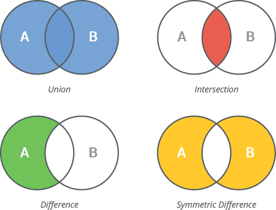

Basic set operations

Because locating items in sets is much faster than in lists or tuples ([Stackoverflow](https://stackoverflow.com/a/8929445)), sets are often used for comparisons between collections of items. On the downside, sets are unordered and allow no duplicates (like dictionary keys).

Example:

```python
A = {3,6,8}
B = {6,7}

print(A & B)  # A ∩ B (intersection)
```

Operators/methods to update sets:

```
set1.add(element)
set1.remove(element)  # see also: set1.discard(element), set1.pop()
set1 |= set2  # set1.update(coll) -> add elements to set1
set1 &= set2  # set1.interesection_update
set1 -= set2  # set1.difference_update
set1 ^= set2  # set1.symmetric_difference_update(coll)
```

1. Your colleague compiled a list of sequence identifiers they want to use in the experiment: `best_seqids = ['f3', 'g9','e2','r0']`. Another colleague compiled another list of sequence identifiers they want to use in the experiment: `optimal_seqids = ['e2','e3','e4','f3','n1']`
   - Determine how many distinct sequence identifiers are in both lists.
   - Determine which identifiers are only in the first list.
   - Determine which identifiers are unique in each one of the lists.